# test

Ziying An

2022-04-11

The data is collected during 2020.3-2020.10

```r
setwd("~/Documents/R files/STATS 531 final cases")
library(tidyverse)
library(pomp)
week = seq(1,232,7)
```

# Model Construction

The series is collected during 2020.3-2020.10. Turkey government [1] posted some restrictions during April and COVID-19 developed a new variant later that year. So we developed a SEIREIR model to simulated the process of reported infected cases.

The SEIREIR model consists of 7 states:

- $S$ is the number of susceptible people who can be exposed to both original and beta variant.
- $E_o$ is the population exposed to the original variant.
- $I_o$ is the infected and infectious population of the original variant.
- $R_o$ is population recovered from original COVID. They can also be infected by beta variant (with a different infecting rate).
- $E_b$ is the population exposed to the beta variant.
- $I_b$ is the infected and infectious population of the beta variant.
- $R_b$ is population recovered from beta COVID.

The population transfering between the states is simulated as:

$$dSE_o(t) ~\sim
bin(S,1-exp(-Beta_o*I_o/N*dt)$$

$$dEI_o(t) ~\sim
bin(E_o,1-exp(-mu_{EI_o}*dt))$$
$$dIR_o(t) ~\sim
bin(I_o,1-exp(-mu_{IR_o}*dt))$$
$$dSE_b(t) ~\sim
bin(S,1-exp(-Beta_b*I_b/N*dt)$$

$$dRE_b(t) ~\sim
bin(R_o,1-exp(-Beta_r*I_b/N*dt)$$

Since Turkey took actions to fight against COVID in April, we use $\beta_{or}$ and $\mu_{IR_r}$ instead of the original parameter after the restrictions took place.

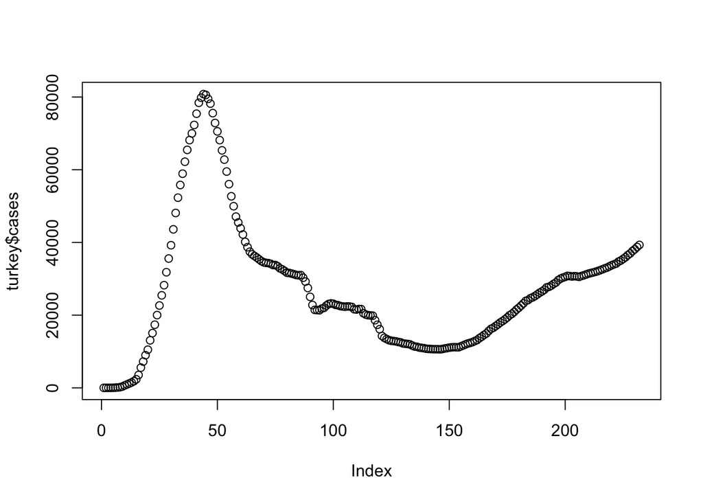

```r
turkey = read.csv("covid_19_data_tr.csv")
turkey$day = 1:nrow(turkey)
#turkey = turkey[,-c(1,2)]
turkey$cases = turkey$Confirmed - turkey$Deaths - turkey$Recovered
plot(turkey$cases)
```

```r
week_cases = turkey$cases[1:232:7]
```

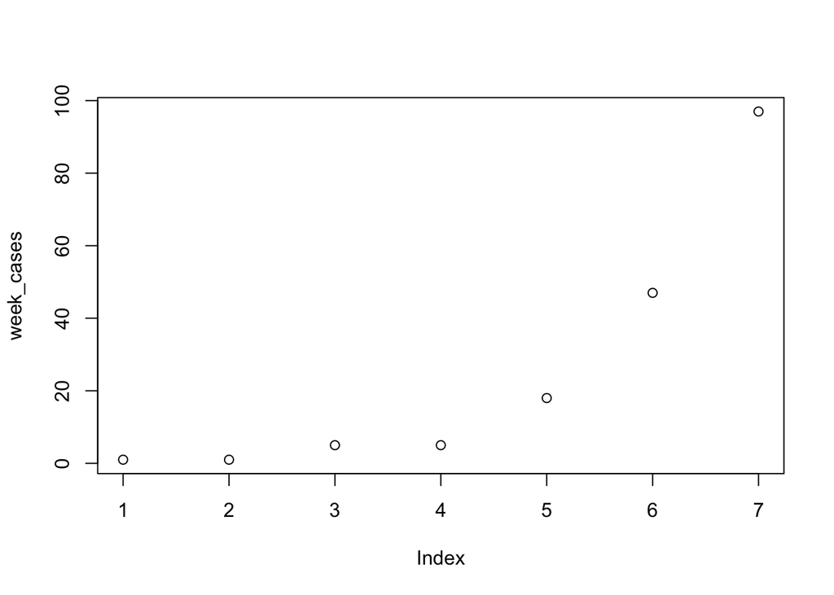

```r
plot(week_cases)
```

We implement the model as follows:

```r
seireir_step <- Csnippet("
  double dN_SE_o = rbinom(S,1-exp(-Beta_o*I_o/N*dt));
  double dN_EI_o = rbinom(E_o,1-exp(-mu_EI_o*dt));
  double dN_IR_o = rbinom(I_o,1-exp(-mu_IR_o*dt));

  if (t>35){
    dN_SE_o = rbinom(S,1-exp(-Beta_or*I_o/N*dt));
    dN_EI_o = rbinom(E_o,1-exp(-mu_EI_o*dt));
    dN_IR_o = rbinom(I_o,1-exp(-mu_IR_r*dt));
  }
  double dN_RE_b = rbinom(R_o,1-exp(-Beta_r*I_b/N*dt));
  double dN_SE_b = rbinom(S-dN_SE_o,1-exp(-Beta_b*I_b/N*dt));
  double dN_EI_b = rbinom(E_b,1-exp(-mu_EI_b*dt));
  double dN_IR_b = rbinom(I_b,1-exp(-mu_IR_b*dt));
  double e = 0;
  if (t == 125) e = 10;
  S -= (dN_SE_o + dN_SE_b);
  E_o += dN_SE_o - dN_EI_o;
  I_o += dN_EI_o - dN_IR_o;
  R_o += dN_IR_o - dN_RE_b;
  E_b += dN_SE_b + dN_RE_b - dN_EI_b + e;
  I_b += dN_EI_b - dN_IR_b;
  R_b += dN_IR_b;
  H += (dN_IR_o + dN_IR_b);
")

seireir_init <- Csnippet("
  S = nearbyint(eta*N);
  E_o = 0;
  I_o = 100;
  R_o = 0;
  E_b = 0;
  I_b = 0;
  R_b = nearbyint((1-eta)*N);
  H = 0;
")

dmeas <- Csnippet("
  lik = dnbinom_mu(reports,k,rho*H,give_log);

  ")

rmeas <- Csnippet("
  reports = rnbinom_mu(k,rho*H);
  ")

turkey %>%
  select(day,reports=cases) %>%
  filter(day<=232) %>%
  pomp(
    times="day",t0=0,
    rprocess=euler(seireir_step,delta.t=1/6),
    rinit=seireir_init,
    rmeasure=rmeas,
    dmeasure=dmeas,
    accumvars="H",
    statenames=c("S","E_o","I_o","R_o","E_b","I_b","R_b","H"),
    paramnames=c("Beta_o","Beta_b","Beta_r","mu_EI_o","mu_IR_o",
                 "Beta_or","mu_IR_r",
                 "mu_EI_b","mu_IR_b","eta","rho","k","N"),
    params=c(Beta_o=20,Beta_b = 50,Beta_or = 1, Beta_r = 50,mu_EI_o=0.18,
             mu_IR_o = 0.02,mu_EI_b = 0.05,mu_IR_r = 0.02,
             mu_IR_b=0.01,rho=0.6,k=10,eta=0.1,N=84340000)
  ) -> measSEIREIR
```

Try a p-filter with the model. We can see the log likelihood is stable after t=20. The model doesn’t fit the starting points well but it has good overall performance.

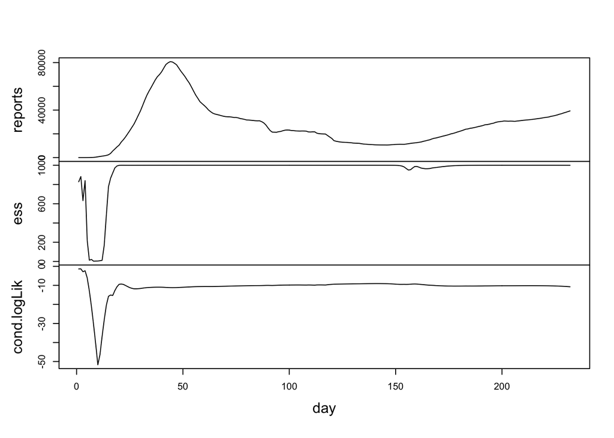

```r
measSEIREIR %>%
  pfilter(Np=1000) -> pf
plot(pf)
```

Simulate the time series with some parameters and see the performance.

```r
measSEIREIR %>%
simulate(
params=c(Beta_o=20,Beta_b = 50,Beta_or = 1, Beta_r = 50,mu_EI_o=0.18,
             mu_IR_o = 0.02,mu_EI_b = 0.05,mu_IR_r = 0.02,
             mu_IR_b=0.01,rho=0.6,k=10,eta=0.1,N=84340000),
nsim=20,format="data.frame",include.data=TRUE
) -> sims

sims %>%
ggplot(aes(x=day,y=reports,group=.id,color=.id=="data"))+
geom_line()+
guides(color="none")
```

[output not shown]

```r
fixed_params <- c(N=84340000, mu_IR_o = 0.05,mu_IR_r = 0.03,
             mu_IR_b=0.01,k=10)
coef(measSEIREIR,names(fixed_params)) <- fixed_params
library(foreach)
library(doParallel)
registerDoParallel()
library(doRNG)
registerDoRNG(625904618)
```

```r
params <- c(Beta_o=20,Beta_b = 50,Beta_or = 1, Beta_r = 50,mu_EI_o=0.18,
             mu_IR_o = 0.02,mu_EI_b = 0.05,mu_IR_r = 0.02,
             mu_IR_b=0.01,rho=0.6,k=10,eta=0.1,N=84340000)
measSEIREIR %>%
  pomp(
    partrans=parameter_trans(log=c("Beta_o","Beta_b","Beta_r","Beta_or"),
                             logit=c("rho","mu_EI_o","mu_EI_b","eta")),
    paramnames=c("Beta_o","Beta_b","Beta_r","Beta_or","rho","mu_EI_o","mu_EI_b","eta"),
  ) -> measSEIREIR2
bake(file="local_search.rds",{
  registerDoRNG(482947940)
  foreach(i=1:20,.combine=c) %do% {
    library(pomp)
    library(tidyverse)
    measSEIREIR2 %>%
      mif2(
        params=params,
        Np=200, Nmif=232,
        cooling.fraction.50=0.5,
        rw.sd=rw.sd(Beta_o=0.003,Beta_b = 0.002,Beta_or = 0.002,
                    Beta_r = 0.002,mu_EI_o=0.002,mu_EI_b = 0.002,
             rho=0.002,eta=ivp(0.001))
      )
  } -> mifs_local
  mifs_local
}) -> mifs_local
```

```r
mifs_local %>%
  traces() %>%
  melt() %>%
  ggplot(aes(x=iteration,y=value,group=L1,color=factor(L1)))+
  geom_line()+
  guides(color="none")+
  facet_wrap(~variable,scales="free_y")
```

[output not shown]

```r
see = mifs_local %>%
  traces() %>%
  melt()
foreach(mf=mifs_local,.combine=rbind) %dopar% {
  library(pomp)
  library(tidyverse)
  evals <- replicate(10, logLik(pfilter(mf,Np=5000)))
  ll <- logmeanexp(evals,se=TRUE)
  mf %>% coef() %>% bind_rows() %>%
    bind_cols(loglik=ll[1],loglik.se=ll[2])
} -> local_results


save(list = c('local_results'),file = 'local.RData')
```

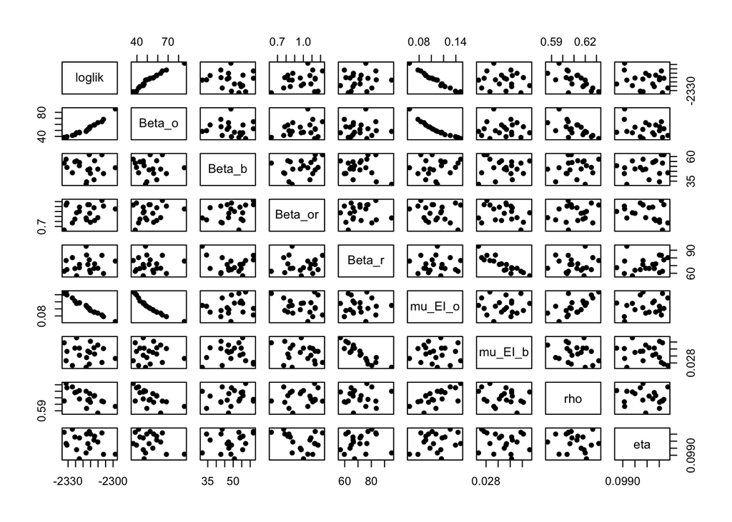

```r
load('local.RData')
pairs(~loglik+Beta_o+Beta_b+Beta_or+Beta_r+mu_EI_o+mu_EI_b+
      rho+eta,data=local_results,pch=16)
```

```r
set.seed(2062379496)
runif_design(
lower = c(Beta_o=1,Beta_b = 50,Beta_or = 0.5,
                    Beta_r = 30,mu_EI_o=0.1,mu_EI_b = 0.03,
             rho=0.2,eta = 0),

upper=c(Beta_o=100,Beta_b = 140,Beta_or = 10,
                    Beta_r = 70,mu_EI_o=0.3,mu_EI_b = 0.2,
             rho=1,eta = 1),
nseq=160
) -> guesses
```

```r
mf1 <- mifs_local[[1]]
```

```r
bake(file="global_search.rds",{
  foreach(guess=iter(guesses,"row"), .combine=rbind) %dopar% {
  library(pomp)
  library(tidyverse)
  mf1 %>%
    mif2(params=c(guess,fixed_params)) %>%
    mif2(Nmif=232) -> mf
  replicate(
    10,
    mf %>% pfilter(Np=50) %>% logLik()
    ) %>%
    logmeanexp(se=TRUE) -> ll
  mf %>% coef() %>% bind_rows() %>%
    bind_cols(loglik=ll[1],loglik.se=ll[2])
} -> results
  results
}) -> global_results

save(list = c('global_results'),file = 'global.RData')
```

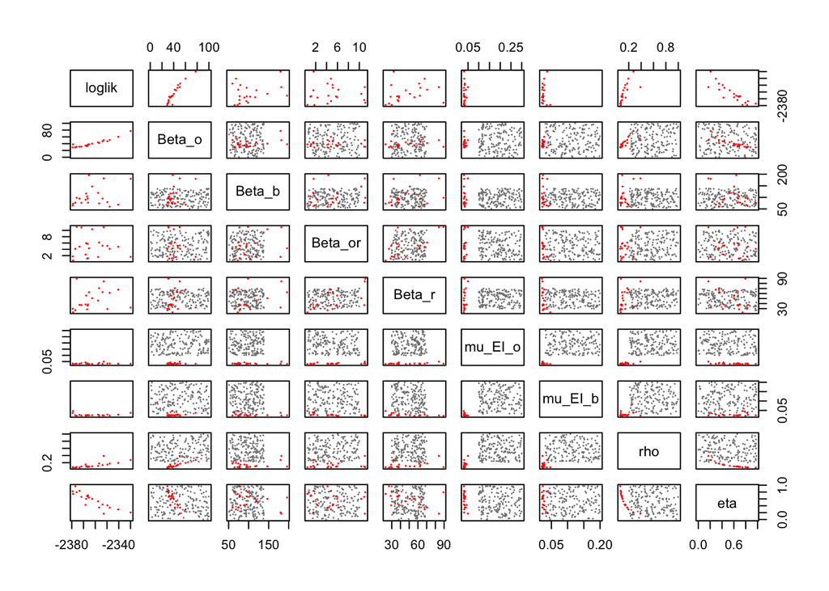

```r
load('global.RData')
global_results %>%
  bind_rows(global_results) %>%
  filter(is.finite(loglik)) %>%
  arrange(-loglik) %>%
  filter(loglik>max(loglik)-50) %>%
  bind_rows(guesses) %>%
  mutate(type=if_else(is.na(loglik),"guess","result")) %>%
  arrange(type) -> all

pairs(~loglik+Beta_o+Beta_b+Beta_or+Beta_r+mu_EI_o+mu_EI_b+
      rho+eta, data=all, pch=16, cex=0.3,
      col=ifelse(all$type=="guess",grey(0.5),"red"))
```

# References

1. https://en.wikipedia.org/wiki/COVID-19_pandemic_in_Turkey#April_2020:_Restrictions_continue